# emerging infectious disease

24 Nov 2025

## emerging and re-emerging disease

Basically, anything we’re worried about

- **emerging**: new to a host: most often (in humans) via *zoonotic spillover*, but could be an existing disease that is expanding its range/becoming more infectious, virulent, whatever
- *re-emerging*: a parasite that was previously thought to be controlled, but is of renewed concern. Due to socioeconomic change, landscape change, climate change, evolution of antibiotic/antiviral resistance, etc.)
- **encounter filter**: changing patterns of reservoir host/vector distribution (due to climate/landscape change), human contact, …
- **compatibility filter**: changes via mutation, recombination, selection for resistance, …
- **disease triangle** (from plant pathology): need co-occurring host, pathogen, environment (for transmission: also consider virulence, treatment resistance …)
- Local change > global change
- Parasites may get better, or worse, or different due to changes …

## Malaria in North America

- established by immigration of enslaved people from west Africa
- landscape change (agricultural clearance/hydrological changes)
- well established by 1850s except in northern/high-altitude/arid places
- poorly diagnosed, haphazardly treated
- decline due to drainage 1900-1920
- 5000 deaths/year (1930s) -> <10 (1950s)
- improvements in nutrition, medical care, housing, insecticides

> We now know that anopheline mosquito breeding throughout the country was sufficiently low so that it was difficult for overseas malaria to become established inside the country, and that the prognostication of a wide spread development of overseas malaria in the American anophelines was based on a failure to consider the very great reduction in mosquito breeding which had occurred since 1931.

Faust (1951)

$R_0$ for vector borne diseases = ($R_0$ vector-to-host $\times$ $R_0$ host-to-vector): proportional to mosquito-to-human ratio (but preventing bites reduces both components)

## Malaria changes

Often driven by **local** landscape change:

- Combinations of hydrological cycle, temperature, predators: e.g. brick-making pits in western Kenya (J. C. Carlson et al., 2004)
- MacDonald & Mordecai (2019): deforestation increases malaria, but malaria decreases deforestation (statistical model, we don’t know the mechanism: ecological change, increased human-vector contact?)

## Mosquito-borne diseases in ‘temperate’ countries

- ‘autochthonous’/‘local transmission events’
- doesn’t mean $R_0 > 1$, but does mean $R_0 > 0$ …
- local transmission of:
  - chikungunya (*Aedes albopictus*, *A. aegypti*: Europe, North America) [New York state, 2025] (Disease Control, 2025; Health, 2025)
  - Zika (Florida, Texas) (*Aedes*)
  - dengue (Argentina, California, Florida, Texas (Barrenechea et al., 2025; Centers for Disease Control, 2025)) (*Aedes*)
  - malaria (DeVita et al., 2025) (*Anopheles* mosquito spp)

## *Candida auris*

- Casadevall et al. (2019); Casadevall et al. (2021); De Gaetano et al. (2024)
- newly emerging fungal pathogen (first isolated 2009)
- not found in fungal collections before 1996
- molecular clocks: disease-causing clades MRCA ~ 37 years ago
- multidrug resistant
- heat-tolerant (up to 42°, more than nearest relatives - fever-tolerant?)
- newly virulent? newly resistant? newly heat-tolerant?
- hypothesis: selection for thermotolerance in the wild, followed by dissemination by birds/agriculture (??)

> Support for the hypothesis would consist of finding more *C. auris* isolates with borderline mammalian thermotolerance and perhaps that these isolates can be adapted to grow at higher temperatures through laboratory selection for growth at higher temperatures.

Money (2024):

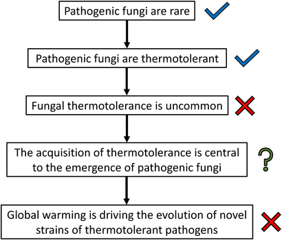

> The increase in global temperature of 1°C (2°F) over the last century is too small to have pushed purely saprotrophic fungi unable to grow at 37°C past this thermal barrier and to assume pathogenic behavior. It seems more likely that C. auris was primed for pathogenicity as one of the many thermotolerant saprotrophs, and acquired azole resistance through an unknown mechanism. This enabled its dissemination as a nosocomial infection when it was introduced to the hospital environment.

## *Batrachochytrium dendrobatidis*

- fungal pathogen
  - most other chytrids are saprophytes, plant pathogens
  - *B. salamandrivorans*: salamander pathogen (more restricted)
- first discoved in poison dart frogs
- caused die-offs in E Australia, Central America, Colorado, California …
- association with high altitude?

Very confusing …

- declines occurred in pristine areas (probably not anthropogenic?)
- some species decline in the absence of Bd
- some species stable in the presence of Bd
- **tipping point hypothesis**: in populations all the time, but something happened to increase virulence/reduce tolerance or resistance ($\approx$ compatibility filter)
  - climate change/El Niño ?
  - ultraviolet radiation?
  - pesticides?
  - combination (species × temperature × U/V × pesticide × …)? (Pounds et al., 2006; Rohr et al., 2008; Rohr & Raffel, 2010)
- **novel pathogen hypothesis**: mutation/speciation + dispersal
  - detection in historical specimens: CA/bullfrog, Brazil …
  - genomics (challenging!)
  - Asian sampling

Fisher & Garner (2020)

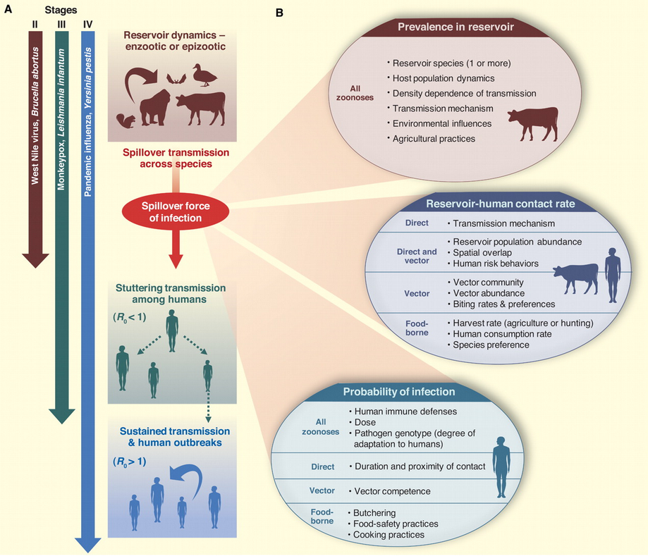

## theory

Do we need to understand *everything*?

- reservoir ecology
- pathogen biology
- human-reservoir interactions

How do we understand? How do we predict?

## effects of climate change

- warming
  - ‘good’ or ‘bad’ for pathogens?
  - vector biology
    - extended range
    - higher activity?
    - lots of debate (Omumbo et al., 2011)
    - details of temperature sensitivity: e.g. Mordecai et al. (2013); Ryan et al. (2015); Mordecai et al. (2020): shift from *Anopheles gambiae* to *Aedes aegypti*, malaria to arboviruses (dengue, chikungunya etc.);
- changes in seasonality, hydrological cycles
- local landscape change
  - hydrology
  - suburbanization and reforestation: Lyme disease
  - deforestation (MacDonald & Mordecai, 2019)
- changes in reservoir communities

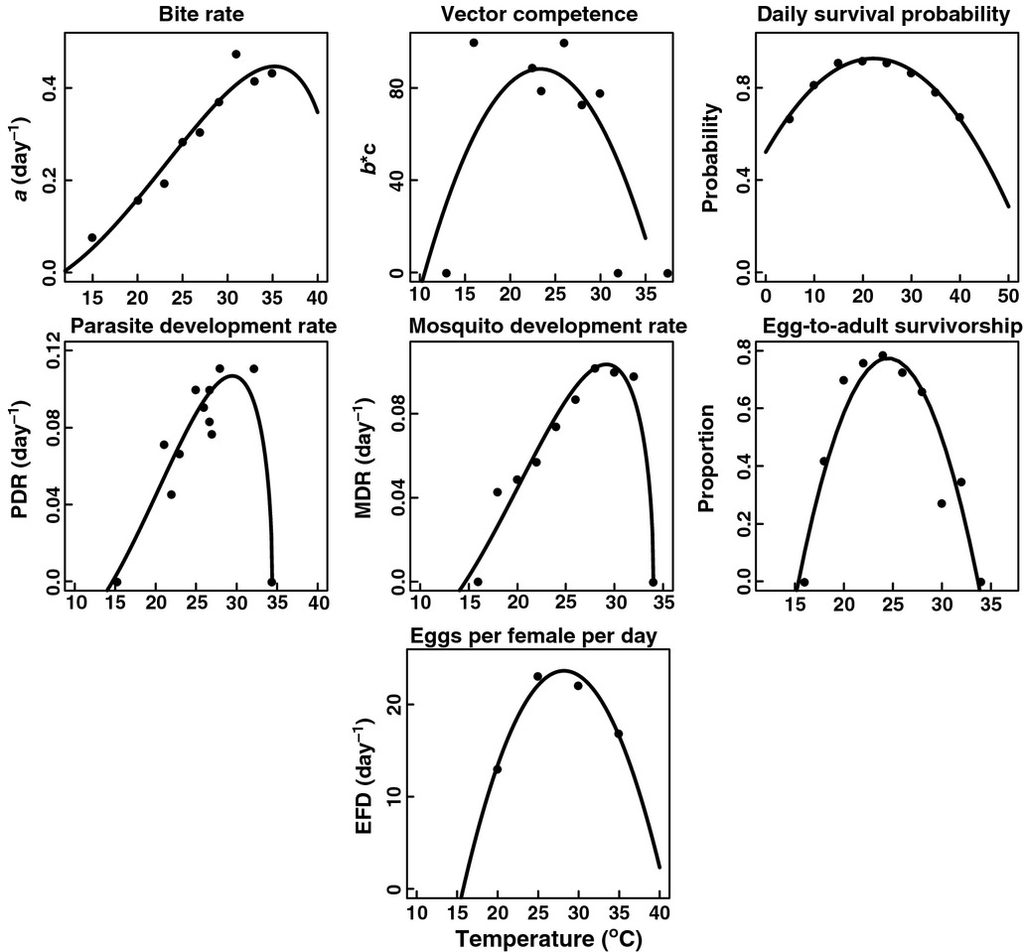

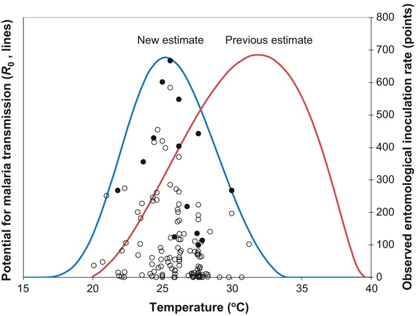

## effects of biodiversity change: dilution effect (Keesing & Ostfeld, 2021)

- does increased biodiversity decrease disease?
  - what does an “effect of biodiversity” really mean? nature can’t count species
  - in what way/why is biodiversity changing?
    - comparing different intact communities?
    - loss of species due to habitat change etc ??
- variation in hosts
  - population density
  - vector competence
  - host competence
  - competitive ability
  - habitat preferences
- encounter reduction (less probability of finding a good host)
- host regulation (fewer good hosts)
- vector preferences (affects which hosts are used)
- **if** high-quality hosts decrease with increasing biodiversity, then decreases in diversity → increased parasite prevalence
- depends on how the community is changing
  - what is driving biodiversity loss?
  - what species are more likely to be lost?
  - are less/more **competent** host species more likely to be lost?
- zoonotic host diversity in human-impacted landscapes (Gibb et al., 2020)

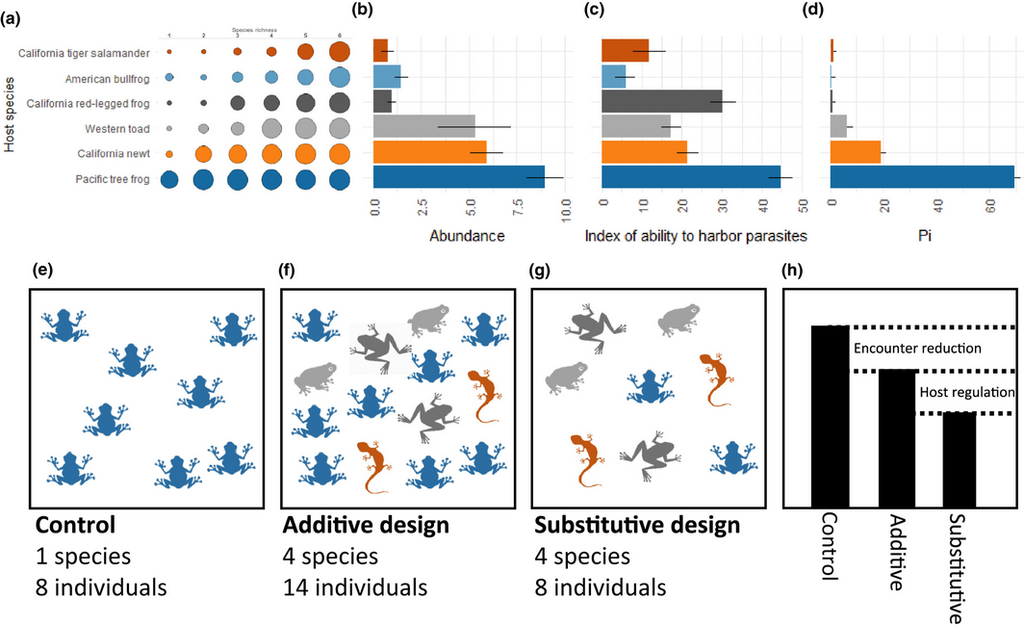

Kain & Bolker (2019):

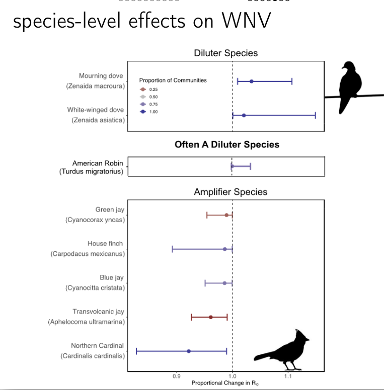

Rohr et al. (2020): meta-analysis (again …)

Resolving two contradictory meta-analysis: experimental vs observational, small- vs large-scale …

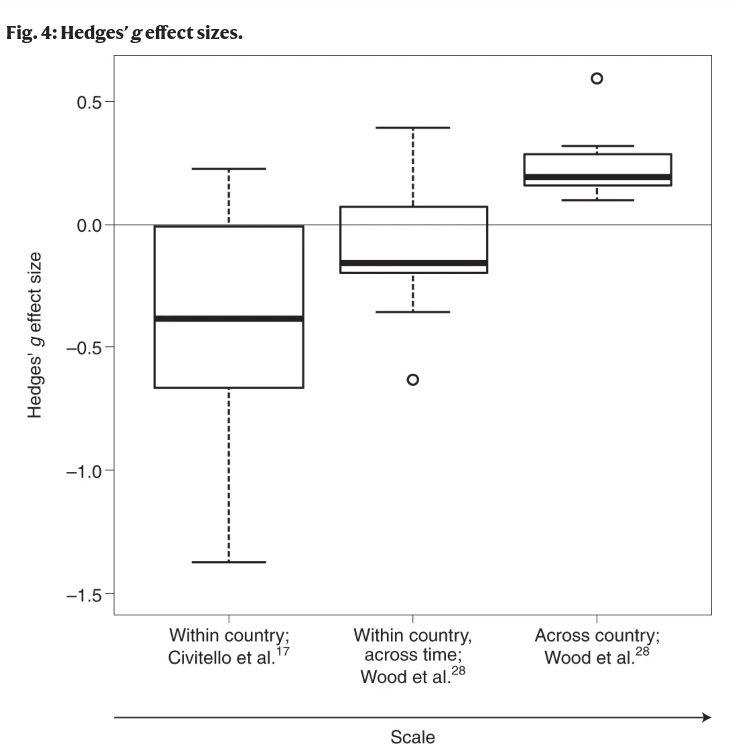

- C. J. Carlson et al. (2022): *higher* rodent diversity and climate anomalies drive plague spillover

## surveillance and prediction

- which viruses will emerge, where, why?

Pulliam & Dushoff (2009): predict zoonotic transmission of livestock viruses

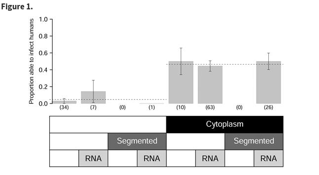

Walker et al. (2018): predict human transmission ability of zoonotic viruses

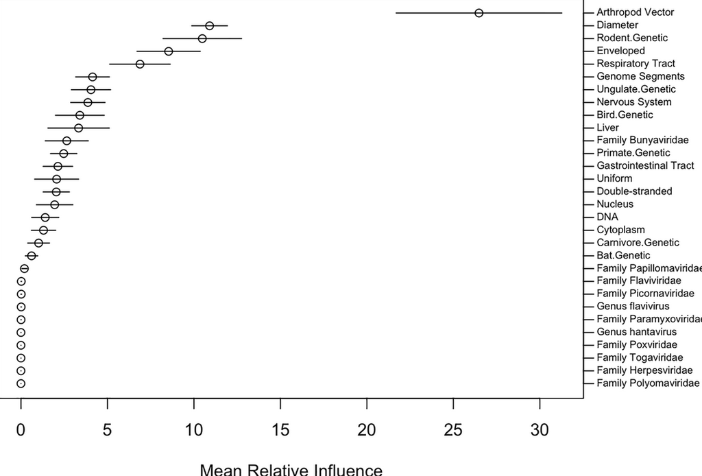

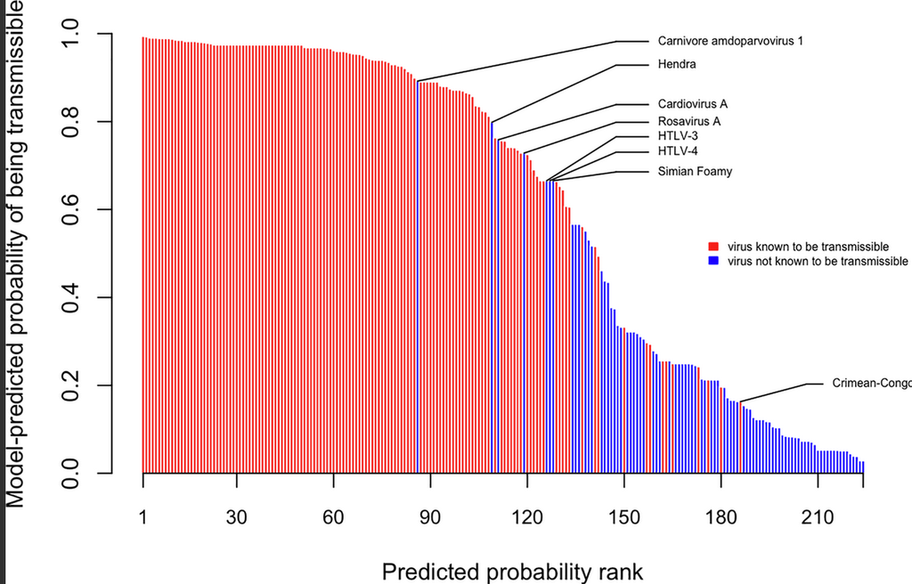

Han et al. (2020): model rodent life history

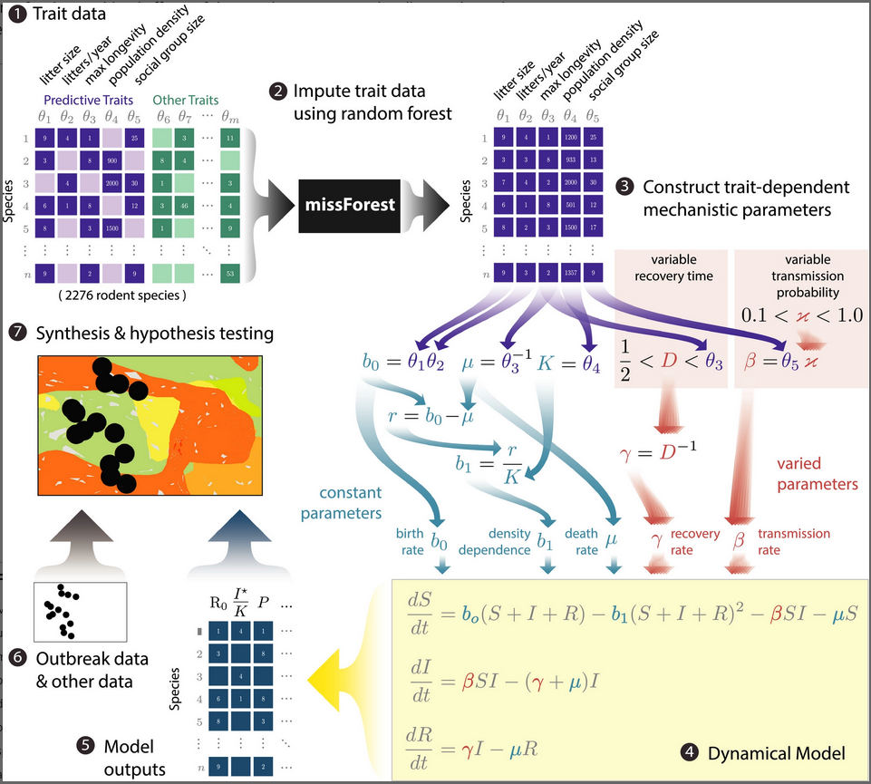

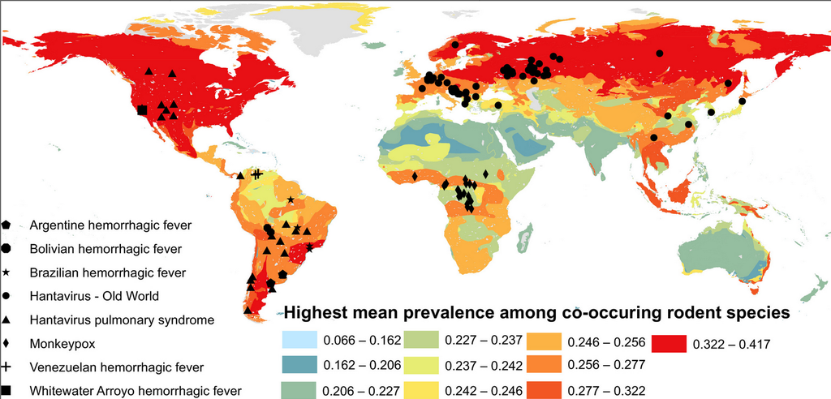

## So what should we do?

- surveillance in the wild
  - Evans et al. (2023): 2017-2020 sample: 12% of 693 individuals sampled in Myanmar were seropositive for sarbecovirus, more likely if they were loggers/hunters or had been exposed to bats …
- improve public health infrastructure!
- improve global health communication
- large-scale genomic sampling (Kawasaki et al., 2021; Lauber & Seitz, 2022)
- prepare antivirals and vaccines

## References

Barrenechea, G. G., Sánchez, R., Calderón, O. C., Buffone, I. R., & Bastos, L. S. (2025). Characterization of the most austral autochthonous dengue outbreak reported in the world (city of Bahía Blanca, Argentina, January–June 2024). A cross-sectional study. *The Lancet Regional Health – Americas*, *51*. https://doi.org/10.1016/j.lana.2025.101254

Carlson, C. J., Bevins, S. N., & Schmid, B. V. (2022). Plague risk in the western United States over seven decades of environmental change. *Global Change Biology*, *28*(3), 753–769. https://doi.org/10.1111/gcb.15966

Carlson, J. C., Byrd, B. D., & Omlin, F. X. (2004). Field assessments in western Kenya link malaria vectors to environmentally disturbed habitats during the dry season. *BMC Public Health*, *4*(1), 33. https://doi.org/10.1186/1471-2458-4-33

Casadevall, A., Kontoyiannis, D. P., & Robert, V. (2019). On the Emergence of *Candida auris*: Climate Change, Azoles, Swamps, and Birds. *mBio*, *10*(4), e01397–19. https://doi.org/10.1128/mBio.01397-19

Casadevall, A., Kontoyiannis, D. P., & Robert, V. (2021). Environmental *Candida auris* and the Global Warming Emergence Hypothesis. *mBio*, *12*(2), 10.1128/mbio.00360–21. https://doi.org/10.1128/mbio.00360-21

Centers for Disease Control. (2025). Current Dengue Outbreak. In *Dengue*. https://www.cdc.gov/dengue/outbreaks/2024/index.html.

De Gaetano, S., Midiri, A., Mancuso, G., Avola, M. G., & Biondo, C. (2024). *Candida auris* Outbreaks: Current Status and Future Perspectives. *Microorganisms*, *12*(5), 927. https://doi.org/10.3390/microorganisms12050927

DeVita, T. N., Morrison, A. M., Stanek, D., Drennon, M., Sarney, E., Brennan, W., Tomson, K., Blackmore, C., Broussard, K., Duwell, M., Blythe, D., Rothfeldt, L., Dulski, T., Blount, K., Ledford, S., Blackburn, D., Wallender, E., Barratt, J. L. N., Raphael, B. H., … McElroy, P. D. (2025). Public Health Response to the First Locally Acquired Malaria Outbreaks in the US in 20 Years. *JAMA Network Open*, *8*(10), e2535719. https://doi.org/10.1001/jamanetworkopen.2025.35719

Disease Control, C. for. (2025). Chikungunya in the United States. In *Chikungunya Virus*. https://www.cdc.gov/chikungunya/data-maps/chikungunya-us.html

Evans, T. S., Tan, C. W., Aung, O., Phyu, S., Lin, H., Coffey, L. L., Toe, A. T., Aung, P., Aung, T. H., Aung, N. T., Weiss, C. M., Thant, K. Z., Htun, Z. T., Murray, S., Wang, L.-F., Johnson, C. K., & Thu, H. M. (2023). Exposure to diverse sarbecoviruses indicates frequent zoonotic spillover in human communities interacting with wildlife. *International Journal of Infectious Diseases*, *0*(0). https://doi.org/10.1016/j.ijid.2023.02.015

Faust, E. C. (1951). The history of malaria in the United States. *American Scientist*, *39*(1), 121–130. https://www.jstor.org/stable/27826354

Fisher, M. C., & Garner, T. W. J. (2020). Chytrid fungi and global amphibian declines. *Nature Reviews Microbiology*, *18*(6), 332–343. https://doi.org/10.1038/s41579-020-0335-x

Gibb, R., Redding, D. W., Chin, K. Q., Donnelly, C. A., Blackburn, T. M., Newbold, T., & Jones, K. E. (2020). Zoonotic host diversity increases in human-dominated ecosystems. *Nature*, *584*(7821), 398–402. https://doi.org/10.1038/s41586-020-2562-8

Han, B. A., O’Regan, S. M., Paul Schmidt, J., & Drake, J. M. (2020). Integrating data mining and transmission theory in the ecology of infectious diseases. *Ecology Letters*, *23*(8), 1178–1188. https://doi.org/10.1111/ele.13520

Health, N. S. D. of. (2025). *New York State Department of Health Confirms First Locally Acquired Case of Chikungunya in New York State*. https://www.health.ny.gov/press/releases/2025/2025-10-14\_chikungunya

Kain, M. P., & Bolker, B. M. (2019). Predicting West Nile virus transmission in North American bird communities using phylogenetic mixed effects models and eBird citizen science data. *Parasites & Vectors*, *12*(1), 395. https://doi.org/10.1186/s13071-019-3656-8

Kawasaki, J., Kojima, S., Tomonaga, K., & Horie, M. (2021). Hidden Viral Sequences in Public Sequencing Data and Warning for Future Emerging Diseases. *mBio*, *12*(4), 10.1128/mbio.01638–21. https://doi.org/10.1128/mbio.01638-21

Keesing, F., & Ostfeld, R. S. (2021). Dilution effects in disease ecology. *Ecology Letters*, *24*(11), 2490–2505. https://doi.org/10.1111/ele.13875

Lauber, C., & Seitz, S. (2022). Opportunities and Challenges of Data-Driven Virus Discovery. *Biomolecules*, *12*(8), 1073. https://doi.org/10.3390/biom12081073

MacDonald, A. J., & Mordecai, E. A. (2019). Amazon deforestation drives malaria transmission, and malaria burden reduces forest clearing. *Proceedings of the National Academy of Sciences*, *116*(44), 22212–22218. https://doi.org/10.1073/pnas.1905315116

Money, N. P. (2024). Fungal thermotolerance revisited and why climate change is unlikely to be supercharging pathogenic fungi (yet). *Fungal Biology*, *128*(1), 1638–1641. https://doi.org/10.1016/j.funbio.2024.01.005

Mordecai, E. A., Paaijmans, K. P., Johnson, L. R., Balzer, C., Ben-Horin, T., de Moor, E., McNally, A., Pawar, S., Ryan, S. J., Smith, T. C., & Lafferty, K. D. (2013). Optimal temperature for malaria transmission is dramatically lower than previously predicted. *Ecology Letters*, *16*(1), 22–30. https://doi.org/10.1111/ele.12015

Mordecai, E. A., Ryan, S. J., Caldwell, J. M., Shah, M. M., & LaBeaud, A. D. (2020). Climate change could shift disease burden from malaria to arboviruses in Africa. *The Lancet Planetary Health*, *4*(9), e416–e423. https://doi.org/10.1016/S2542-5196(20)30178-9

Omumbo, J. A., Lyon, B., Waweru, S. M., Connor, S. J., & Thomson, M. C. (2011). Raised temperatures over the Kericho tea estates: Revisiting the climate in the East African highlands malaria debate. *Malaria Journal*, *10*(1), 12. https://doi.org/10.1186/1475-2875-10-12

Pounds, A. J., Bustamante, M. R., Coloma, L. A., Consuegra, J. A., Fogden, M. P. L., Foster, P. N., La Marca, E., Masters, K. L., Merino-Viteri, A., Puschendorf, R., Ron, S. R., Sánchez-Azofeifa, G. A., Still, C. J., & Young, B. E. (2006). Widespread amphibian extinctions from epidemic disease driven by global warming. *Nature*, *439*(7073), 161–167. https://doi.org/10.1038/nature04246

Pulliam, J. R. C., & Dushoff, J. (2009). Ability to Replicate in the Cytoplasm Predicts Zoonotic Transmission of Livestock Viruses. *The Journal of Infectious Diseases*, *199*(4), 565–568. https://doi.org/10.1086/596510

Rohr, J. R., Civitello, D. J., Halliday, F. W., Hudson, P. J., Lafferty, K. D., Wood, C. L., & Mordecai, E. A. (2020). Towards common ground in the biodiversity–disease debate. *Nature Ecology & Evolution*, *4*(1), 24–33. https://doi.org/10.1038/s41559-019-1060-6

Rohr, J. R., & Raffel, T. R. (2010). Linking global climate and temperature variability to widespread amphibian declines putatively caused by disease. *Proceedings of the National Academy of Sciences*, *107*(18), 8269–8274. https://doi.org/10.1073/pnas.0912883107

Rohr, J. R., Raffel, T. R., Romansic, J. M., McCallum, H., & Hudson, P. J. (2008). Evaluating the links between climate, disease spread, and amphibian declines. *Proceedings of the National Academy of Sciences*, *105*(45), 17436–17441. https://doi.org/10.1073/pnas.0806368105

Ryan, S. J., McNally, A., Johnson, L. R., Mordecai, E. A., Ben-Horin, T., Paaijmans, K., & Lafferty, K. D. (2015). Mapping Physiological Suitability Limits for Malaria in Africa Under Climate Change. *Vector-Borne and Zoonotic Diseases*, *15*(12), 718–725. https://doi.org/10.1089/vbz.2015.1822

Walker, J. W., Han, B. A., Ott, I. M., & Drake, J. M. (2018). Transmissibility of emerging viral zoonoses. *PLOS ONE*, *13*(11), e0206926. https://doi.org/10.1371/journal.pone.0206926

Last updated: 2025-12-01 10:14:21.512273